# POP77022: Programming Exercise 1

Daniel Murray

## Overview

The first homework assignment will cover concepts and methods from Weeks 1 & 2 (basic string operations, corpus acquisition, text processing, textual statistics, dictionary methods). You are expected to provide your answers as embedded R code and/or text answers in the chunks provided in the homework RMarkdown file.

For example:

```r
print("Print R code in code chunk.")
```

```
## [1] "Print R code in code chunk."
```

```
Describe results and provide answers to conceptual and open-ended questions
in a plain code block like this one.
```

**The programming exercise is worth 20% of your total grade. The questions sum to 100 points.**

## Analysis of tweets during a political crisis

We will start with a dataset that contains almost 900 tweets that were published by four central figures in American politics around the time of the onset of an impeachment inquiry: Pres. Donald Trump, Rudy Giuliani, Speaker of the House Rep. Nancy Pelosi, and Chair of the House Intelligence Committee Rep. Adam Schiff.

The first step will be to read the spreadsheet of tweets into R and then use the `str` and `head` functions to describe the variables and contents of the dataset. For your convenience, I will provide code to import the spreadsheet (*Hint: be sure that the data folder is in the same folder as this homework RMarkdown file.*)

```r
setwd(getwd())
data <- read.csv("./data/us_tweets.csv",
                 stringsAsFactors=FALSE,
                 encoding = "utf-8")

print(str(data))
```

```
## 'data.frame':    899 obs. of  9 variables:
##  $ X             : int  1 2 3 4 5 6 7 8 9 10 ...
##  $ screen_name   : chr  "RudyGiuliani" "RudyGiuliani" "RudyGiuliani" "RudyGiuliani" ...
##  $ text          : chr  "If John Solomon uncovered about Republicans the corruption in Ukraine and at highest levels of US to illegally "| __truncated__ "Democrats now own Biden corruption. His family has been selling Biden’s offices for 5 decades. From sleezy litt"| __truncated__ "Last night on …
##  $ created_at    : chr  "2019-10-03 23:38:05" "2019-10-03 19:44:37" "2019-10-03 19:37:34" "2019-10-03 16:53:03" ...
##  $ source        : chr  "Twitter for iPhone" "Twitter for iPhone" "Twitter for iPhone" "Twitter for iPhone" ...
##  $ is_retweet    : logi  FALSE FALSE FALSE FALSE FALSE FALSE ...
##  $ favorite_count: int  23852 36662 7226 26992 19397 2859 2517 3184 4627 4952 ...
##  $ retweet_count : int  8787 15456 3124 11809 7693 1460 1224 1425 2153 2734 ...
##  $ quote_count   : logi  NA NA NA NA NA NA ...
## NULL
```

```r
print(head(data))
```

```
##   X  screen_name
## 1 1 RudyGiuliani
## 2 2 RudyGiuliani
## 3 3 RudyGiuliani
## 4 4 RudyGiuliani
## 5 5 RudyGiuliani
## 6 6 RudyGiuliani
##                                                                                                                                                                                                                                                                                                          …
## 1                                       If John Solomon uncovered about Republicans the corruption in Ukraine and at highest levels of US to illegally interfere in a Pres. campaign and to buy the office of VP for millions, he would be a hero of Swamp Media. There would be a movie made “Pay for Pl…
## 2                        Democrats now own Biden corruption. His family has been selling Biden’s offices for 5 decades. From sleezy little crooks to doing business with Ukrainian organized crime, Whitey Bulger’s nephew, Chinese government, a Madoff type and lots more. All covered up by Corrupt Me…
## 3                                                                                                                                                                                                                                                             Last night on @LouDobbs https://t.co/68wybe…
## 4 If this is true, that Biden didn’t know about his son’s overseas business dealings, then where else was the son doing business that was in conflict with the best interest of the United States? Russia, Venezuela, Cuba, etc? Of course, it’s a lie. They must think we’re stupid. https://t.co/uWmbpS…
## 5                    Let’s see how crooked Dems and their Corrupt Media can twist a lawful process and make false and defamatory attacks on people. By doing it in secret they are creating a false sense something is wrong. That’s why I put out some of my texts. All at request of and reported to St…
## 6                                                                   This was to set up a conference call for me to report to Ambassadors Volker and Sondland. Crooked Dems are conducting secret, unconstitutional Star Chamber trampling on basic civil rights and minimum fairness. https://t.co/LeGYzl…
##            created_at             source is_retweet favorite_count
## 1 2019-10-03 23:38:05 Twitter for iPhone      FALSE          23852
## 2 2019-10-03 19:44:37 Twitter for iPhone      FALSE          36662
## 3 2019-10-03 19:37:34 Twitter for iPhone      FALSE           7226
## 4 2019-10-03 16:53:03 Twitter for iPhone      FALSE          26992
## 5 2019-10-03 16:01:37 Twitter for iPhone      FALSE          19397
## 6 2019-10-03 15:55:53 Twitter for iPhone      FALSE           2859
##   retweet_count quote_count
## 1          8787          NA
## 2         15456          NA
## 3          3124          NA
## 4         11809          NA
## 5          7693          NA
## 6          1460          NA
```

### Question 1.0 (2 points)

Print the number of tweets that are in this dataset.

```r
# Count number of tweets (observations) in dataset
print(nrow(data))
```

```
## [1] 899
```

### Question 1.1 (3 points)

Create a new dataframe that only includes original tweets (remove retweets) and print the number of rows.

```r
# Remove retweets
df <- data[data$is_retweet == "FALSE",]

# Count number of original tweets
print(nrow(df))
```

```
## [1] 662
```

### Question 1.2 (20 points)

Create a smaller dataframe that only includes tweets by Donald Trump.

- Print how many tweets by Trump are contained in the dataset?

For the following print the number of instances as well as an example tweet:

- How many tweets include an exclamation mark?
- In how many tweets did Trump mention words related to “winning”?
- “employment”?
- “immigration”?
- “hoax”?

Make sure that you support your answers with code.

(*Hints: be sure to use regular expressions when searching the tweets; also you might want to wrap your search term in between word anchor boundaries (`\\b`). For instance, for the term health: `"\\bhealth\\b"`*)

```r
# Create dataset containing only tweets by Donald Trump
df_trump <- df[df$screen_name == "realDonaldTrump",]

# Count number of tweets by Donald Trump and print
print(paste("Number of tweets by Donald Trump:", as.character(nrow(df_trump))))
```

```
## [1] "Number of tweets by Donald Trump: 377"
```

```r
# Count number of tweets containing exclamation mark and print
print(paste("Number of tweets containing exclamation mark:", as.character(nrow(df_trump[grep('!', df_trump$text),]))))
```

```
## [1] "Number of tweets containing exclamation mark: 261"
```

```r
# Print example tweet containing exclamation mark
print(df_trump[grep('!', df_trump$text),]$text[sample(1:as.character(nrow(df_trump[grep('!', df_trump$text),])),1)])
```

```
## [1] "Thank you @foxandfriends and @RepMarkMeadows. Great interview!"
```

```r
# Count number of tweets containing words related to "winning" and print
print(paste("Number of tweets containing words related to 'winning':", as.character(nrow(df_trump[grep('(?i)\\bwin|(?i)\\bvictor', df_trump$text),]))))
```

```
## [1] "Number of tweets containing words related to 'winning': 22"
```

```r
# Print example tweet containing words related to "winning"
print(df_trump[grep('(?i)\\bwin|(?i)\\bvictor', df_trump$text),]$text[sample(1:as.character(nrow(df_trump[grep('(?i)\\bwin|(?i)\\bvictor', df_trump$text),])),1)])
```

```
## [1] "....place in TRADE, it’s taking shape in Military Competition.” Johnathan Ward, author and China expert. We are winning, and we will win. They should not have broken the deal we had with them. Happy Birthday China!"
```

```r
# Count number of tweets containing words related to "employment" and print
print(paste("Number of tweets containing words related to 'employment':", as.character(nrow(df_trump[grep('(?i)employ|(?i)\\bjobs', df_trump$text),]))))
```

```
## [1] "Number of tweets containing words related to 'employment': 6"
```

```r
# Print random example tweet containing words related to "employment"
print(df_trump[grep('(?i)employ|(?i)\\bjobs', df_trump$text),]$text[sample(1:as.character(nrow(df_trump[grep('(?i)employ|(?i)\\bjobs', df_trump$text),])),1)])
```

```
## [1] "Breaking News: Unemployment Rate, at 3.5%, drops to a 50 YEAR LOW. Wow America, lets impeach your President (even though he did nothing wrong!)."
```

```r
# Count number of tweets containing words related to "immigration" and print
print(paste("Number of tweets containing words related to 'immigration':", as.character(nrow(df_trump[grep('(?i)\\bimmigr', df_trump$text),]))))
```

```
## [1] "Number of tweets containing words related to 'immigration': 4"
```

```r
# Print random example tweet containing words related to "immigration"
print(df_trump[grep('(?i)\\bimmigr', df_trump$text),]$text[sample(1:as.character(nrow(df_trump[grep('(?i)\\bimmigr', df_trump$text),])),1)])
```

```
## [1] "....VERY stupidly negotiated Trade Deals, and Illegal Immigration, are a tremendous cost and burden to our Country. They are BOTH coming along very well and someday, in the not too distant future, America will see a very positive change. Remember, America First!"
```

```r
# Count number of tweets containing word "hoax" and print
print(paste("Number of tweets containing word 'hoax':", as.character(nrow(df_trump[grep('(?i)\\bhoax\\b', df_trump$text),]))))
```

```
## [1] "Number of tweets containing word 'hoax': 5"
```

```r
# Print random example tweet containing word "hoax"
print(df_trump[grep("(?i)\\bhoax\\b", df_trump$text),]$text[sample(1:as.character(nrow(df_trump[grep("(?i)\\bhoax\\b", df_trump$text),])),1)])
```

```
## [1] "“The congratulatory phone call with the Ukrainian President was PERFECT, unless you heard Liddle’ Adam Schiff’s fraudulently made up version of the call. This is just another Fake News Media, together with their partner, the Democrat Party, HOAX!"
```

### Question 2 (75 points)

Create a `corpus` and a `dfm` object with processed text (including collocations) using the dataframe generated in Question 1.1. With the generated `dfm` object perform the following tasks:

1. Create a frequency plot of the top 30 tokens for each politician.
2. Determine the “key” terms that Trump and Pelosi are more likely to tweet. Plot your results
3. Perform a keyword in context analysis using your `corpus` object for some of the most distinct keywords from both Trump and Pelosi. *Hint: remember to use the `phrase` function in the `pattern` argument of `kwic`*
4. Conduct a sentiment analysis of Trump’s tweets using the Lexicon Sentiment Dictionary. Plot net sentiment over the entire sample period. Interpret the results. *Hint: you might want to use `lubridate` to generate a date object variable from the “created_at” variable before plotting. For example: `docvars(dfm, "date") <- lubridate::ymd_hms(dfm@docvars$created_at)`*
5. Justify each of your text processing decisions and interpret your results in the text field below. What can we learn about the political communication surrounding the political crisis based on the results from the above tasks?

```r
# Load required libraries
library(quanteda)
library(textstem)
library(quanteda.textstats)
```

```r
library(ggplot2)
library(quanteda.textplots)
library(lubridate)
# Create corpus from dataframe
corpus <- corpus(df,
                 docid_field = "X",
                 text_field = "text")

# Inspect the corpus
summary(corpus, 5)
```

```
## Corpus consisting of 662 documents, showing 5 documents:
##
##  Text Types Tokens Sentences  screen_name          created_at
##     1    41     55         2 RudyGiuliani 2019-10-03 23:38:05
##     2    45     50         4 RudyGiuliani 2019-10-03 19:44:37
##     3     5      5         1 RudyGiuliani 2019-10-03 19:37:34
##     4    47     59         4 RudyGiuliani 2019-10-03 16:53:03
##     5    48     57         4 RudyGiuliani 2019-10-03 16:01:37
##              source is_retweet favorite_count retweet_count quote_count
##  Twitter for iPhone      FALSE          23852          8787          NA
##  Twitter for iPhone      FALSE          36662         15456          NA
##  Twitter for iPhone      FALSE           7226          3124          NA
##  Twitter for iPhone      FALSE          26992         11809          NA
##  Twitter for iPhone      FALSE          19397          7693          NA
```

```r
# Tokenise text and remove punctuation/symbols/URLs, etc.
toks <- quanteda::tokens(corpus,
               include_docvars = TRUE,
               remove_numbers = TRUE,
               remove_punct = TRUE,
               remove_symbols = TRUE,
               remove_hyphens = TRUE,
               remove_separators = TRUE,
               remove_url = TRUE)
# Convert tokens to lowercase
toks <- tokens_tolower(toks)

# Create list of stopwords and remove these from tokens, retaining whitespaces in place of removed stopwords
stop_list <- stopwords("english")
toks <- tokens_remove(toks, stop_list, padding=TRUE)

# Identify trigram collocations and order by frequency
trigrams <- textstat_collocations(toks,
                                  method = "lambda",
                                  size = 3,
                                  min_count = 3,
                                  smoothing = 0.5)

# Sort trigrams by frequency
trigrams <- trigrams[order(trigrams$count, decreasing=TRUE),]
trigrams$collocation
```

```
##  [1] "fake news media"               "new york times"
##  [3] "quid pro quo"                  "#lowerdrugcosts now act"
##  [5] "rep adam schiff"               "make america great"
##  [7] "second hand information"       "keep america great"
##  [9] "radical left democrats"        "another fake news"
## [11] "national security advisor"     "chief standing bear"
## [13] "@realdonaldtrump s abuses"     "failing new york"
## [15] "gun violence epidemic"         "background checks legislation"
## [17] "explicit quid pro"             "prescription drug prices"
## [19] "greatest witch hunt"           "liddle adam schiff"
```

```r
# Filter for meaningful trigram collocations
trigrams <- trigrams[c(1,2,3,4,5,6,7,8,9,11,12,15,16,18),]

# Identify bigram collocations
bigrams <- textstat_collocations(toks,
                                 method = "lambda",
                                 size = 2,
                                 min_count = 3,
                                 smoothing = 0.5)

# Sort bigrams by frequency and inspect most/least frequent
bigrams <- bigrams[order(-bigrams$count),]
head(bigrams$collocation, 25)
```

```
##  [1] "fake news"               "witch hunt"
##  [3] "adam schiff"             "ukrainian president"
##  [5] "united states"           "news media"
##  [7] "new york"                "president trump"
##  [9] "whistleblower complaint" "york times"
## [11] "so-called whistleblower" "republican party"
## [13] "nothing democrats"       "@realdonaldtrump s"
## [15] "joe biden"               "foreign leader"
## [17] "national security"       "gun violence"
## [19] "america great"           "biden family"
## [21] "human rights"            "nancy pelosi"
## [23] "pro quo"                 "quid pro"
## [25] "every day"
```

```r
tail(bigrams$collocation, 25)
```

```
##  [1] "stock market"            "left democrats"
##  [3] "another fake"            "just another"
##  [5] "hunter biden"            "nothing dems"
##  [7] "failing new"             "congress must"
##  [9] "just said"               "courage amp"
## [11] "trump administration"    "rudy giuliani"
## [13] "approval rating"         "chief standing"
## [15] "white supremacist"       "explicit quid"
## [17] "prescription drugs"      "presidential harassment"
## [19] "violence epidemic"       "great news"
## [21] "got caught"              "security advisor"
## [23] "moving forward"          "president trump's"
## [25] "ukraine president"
```

```r
# Create list of bigrams of interest (z-score > 3)
bigrams <- bigrams[bigrams$z > 3,]

# Compile a list of collocations to keep
keep_coll_list <- rbind(trigrams, bigrams)

# Merge collocations with tokens and remove whitespaces and ampersands
toks_col <- tokens_compound(toks, keep_coll_list)
toks_col <- tokens_remove(toks_col, c("","amp"))

# Convert to document feature matrix
dfm <- dfm(toks_col)

# Check top features of dfm
topfeatures(dfm, 50)
```

```
##     president         trump       ukraine           now        people
##            68            68            61            46            43
##     democrats         biden       country         thank         never
##            40            40            40            38            37
##          call          even      election whistleblower      congress
##            35            32            32            31            31
##         great            us           one           big          just
##            31            30            30            30            30
##          time           can        office          done         china
##            30            29            28            28            28
##          must           get         today    corruption           see
##            27            27            27            26            26
##         wrong           new         house  conversation          said
##            25            25            24            24            24
##          made          know         years          like          many
##            23            23            23            23            23
##          much         world    witch_hunt           son          dems
##            22            22            21            20            20
##          help   impeachment         right          make        schiff
##            20            20            20            19            19
```

```r
# Remove features that are unlikely to add insight
dfm <- dfm_remove(dfm, pattern=c("now", "people", "thank",
                             "even","never", "one",
                             "just", "time", "can",
                             "must", "get","said",
                             "like","many", "much"))

# Check top features again
topfeatures(dfm, 50)
```

```
##     president         trump       ukraine     democrats         biden
##            68            68            61            40            40
##       country          call      election whistleblower      congress
##            40            35            32            31            31
##         great            us           big        office          done
##            31            30            30            28            28
##         china         today    corruption           see         wrong
##            28            27            26            26            25
##           new         house  conversation          made          know
##            25            24            24            23            23
##         years         world    witch_hunt           son          dems
##            23            22            21            20            20
##          help   impeachment         right          make        schiff
##            20            20            20            19            19
##       corrupt        trying       history       trump's       nothing
##            19            19            19            19            19
##      millions         media           law          good         obama
##            18            18            18            18            18
##         going          ever          also          vote          want
##            18            18            18            18            17
```

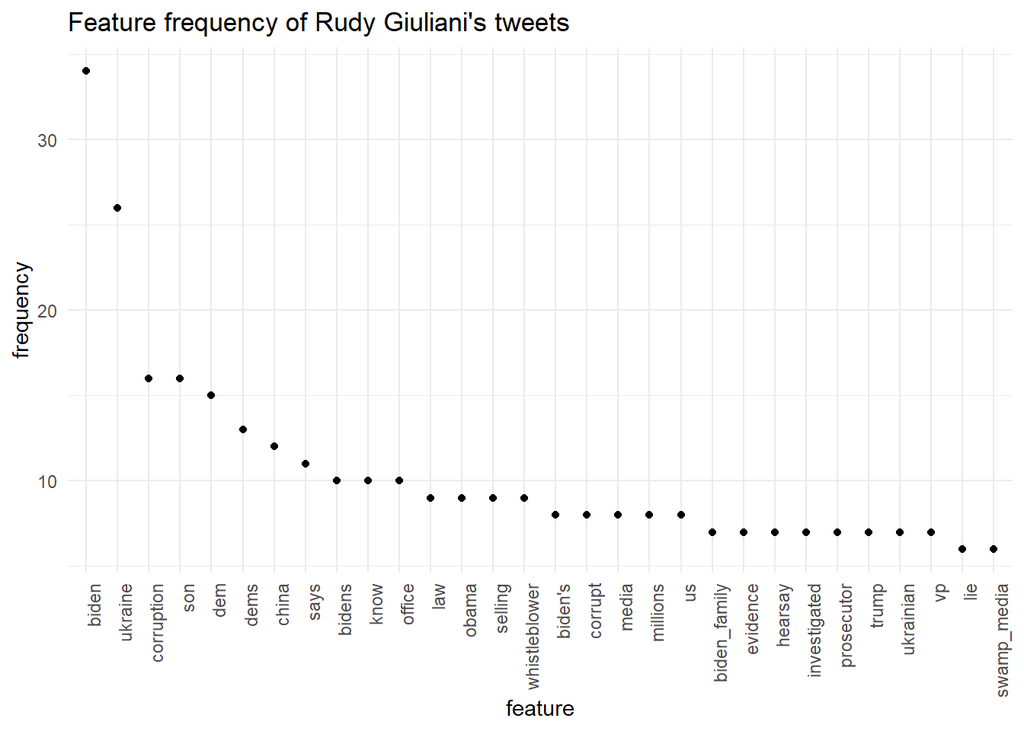

```r
# Save document feature matrix
saveRDS(dfm, "data/dfm")

# Create frequency plot of top 30 tokens for Rudy Giuliani

# Subset dfm for Rudy Giuliani's tweets only
dfm_rg <- dfm_subset(dfm, screen_name == "RudyGiuliani")
dfm_freq_rg <- textstat_frequency(dfm_rg, n = 30)

# Sort features by frequency in descending order
dfm_freq_rg$feature <- with(dfm_freq_rg, reorder(feature, -frequency))

# Plot feature frequencies
ggplot(dfm_freq_rg, aes(x = feature, y = frequency)) + ggtitle("Feature frequency of Rudy Giuliani's tweets") +
       geom_point() + theme_minimal() + theme(axis.text.x = element_text(angle = 90, hjust = 1))
```

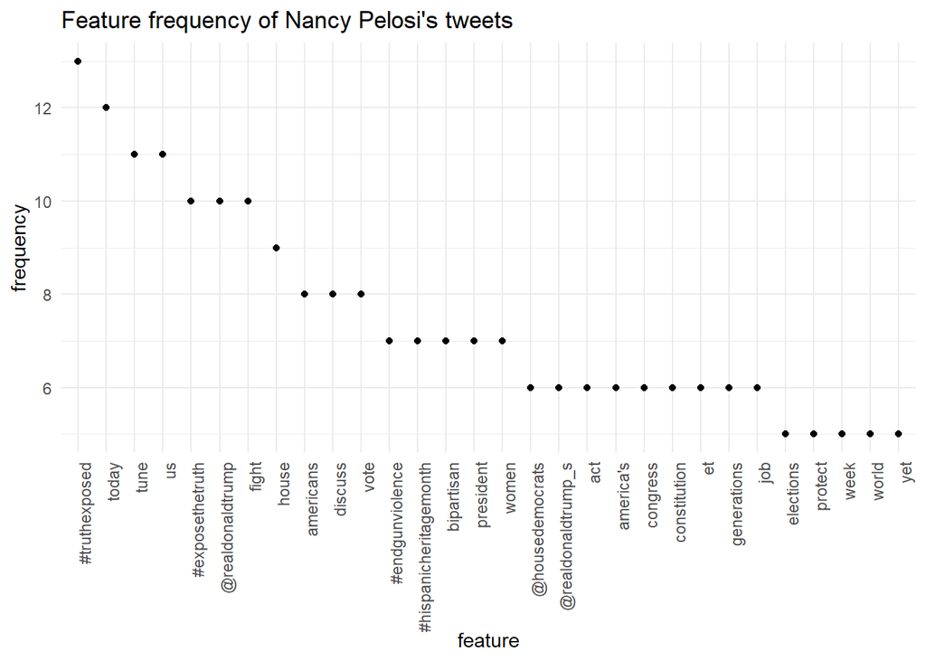

```r
# Create frequency plot of top 30 tokens for Nancy Pelosi

# Subset dfm for Nancy Pelosi's tweets only
dfm_np <- dfm_subset(dfm, screen_name == "SpeakerPelosi")
dfm_freq_np <- textstat_frequency(dfm_np, n = 30)

# Sort features by frequency in descending order
dfm_freq_np$feature <- with(dfm_freq_np, reorder(feature, -frequency))

# Plot feature frequencies
ggplot(dfm_freq_np, aes(x = feature, y = frequency)) + ggtitle("Feature frequency of Nancy Pelosi's tweets") +
       geom_point() + theme_minimal() + theme(axis.text.x = element_text(angle = 90, hjust = 1))
```

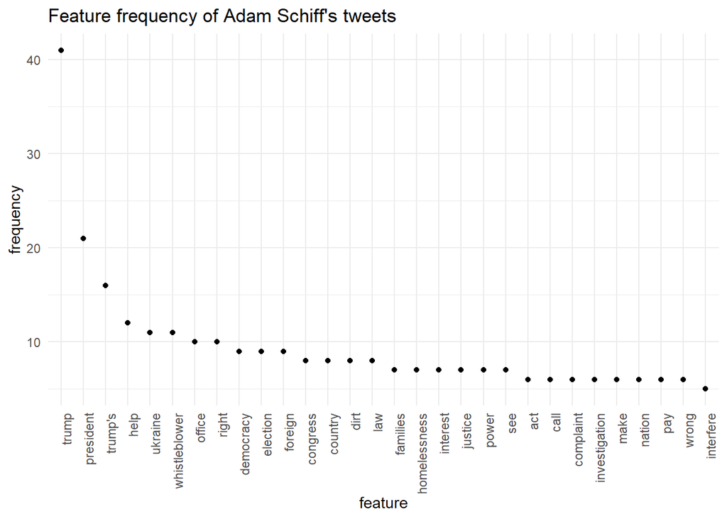

```r
# Create frequency plot of top 30 tokens for Adam Schiff

# Subset dfm for Adam Schiff's tweets only
dfm_as <- dfm_subset(dfm, screen_name == "RepAdamSchiff")
dfm_freq_as <- textstat_frequency(dfm_as, n = 30)

# Sort features by frequency in descending order
dfm_freq_as$feature <- with(dfm_freq_as, reorder(feature, -frequency))

# Plot feature frequencies
ggplot(dfm_freq_as, aes(x = feature, y = frequency)) + ggtitle("Feature frequency of Adam Schiff's tweets") +
       geom_point() + theme_minimal() + theme(axis.text.x = element_text(angle = 90, hjust = 1))
```

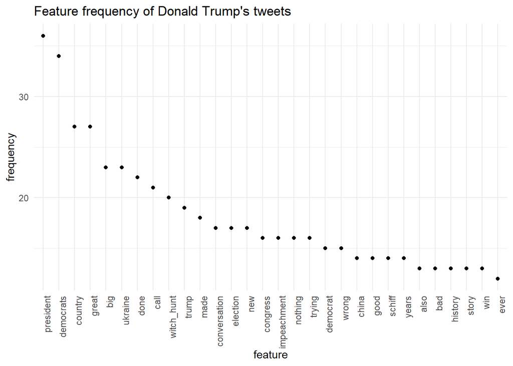

```r
# Create frequency plot of top 30 tokens for Donald Trump

# Subset dfm for Donald Trump's tweets only
dfm_dt <- dfm_subset(dfm,
                     screen_name == "realDonaldTrump")
dfm_freq_dt <- textstat_frequency(dfm_dt, n = 30)

# Sort features by frequency in descending order
dfm_freq_dt$feature <- with(dfm_freq_dt, reorder(feature, -frequency))

# Plot feature frequencies
ggplot(dfm_freq_dt, aes(x = feature, y = frequency)) + ggtitle("Feature frequency of Donald Trump's tweets") +
       geom_point() + theme_minimal() + theme(axis.text.x = element_text(angle = 90, hjust = 1))
```

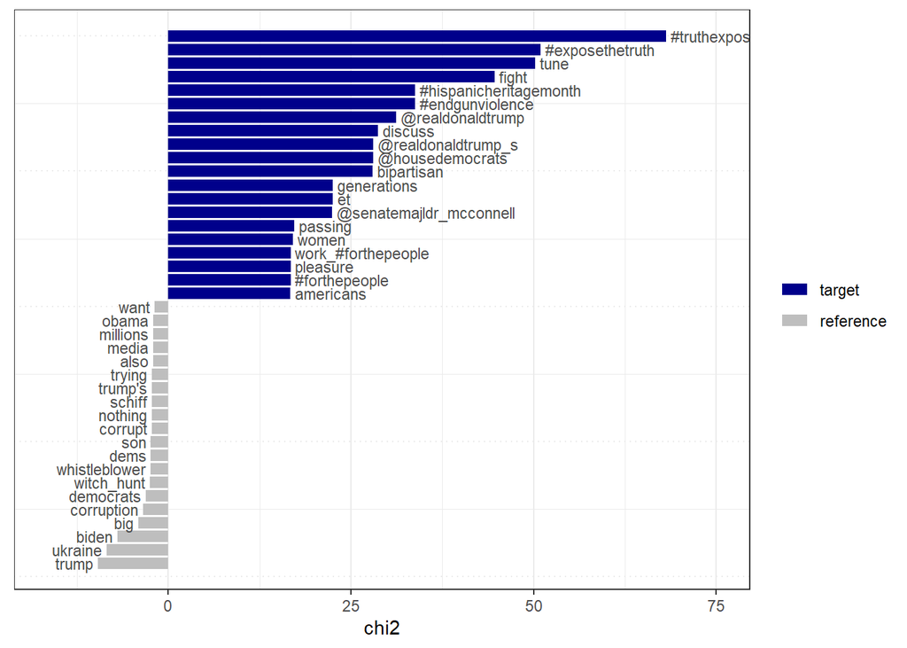

```r
# Determine "key" terms that Nancy Pelosi is more likely to tweet
# Calculate keyness and set the Nancy Pelosi as the target group
keyness_stat_np <- textstat_keyness(dfm, target = docvars(dfm, "screen_name") == "SpeakerPelosi")

# Plot keyness calculations
textplot_keyness(keyness_stat_np, labelsize = 3)
```

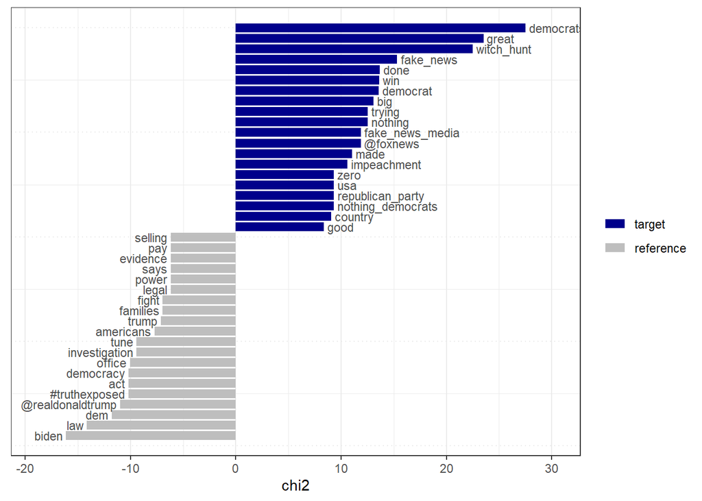

```r
# Determine "key" terms that Donald Trump is more likely to tweet
# Calculate keyness and set the Donald Trump as the target group
keyness_stat_dt <- textstat_keyness(dfm, target = docvars(dfm, "screen_name") == "realDonaldTrump")

# Plot keyness calculations
textplot_keyness(keyness_stat_dt, labelsize = 3)
```

```r
# Perform a keyword in context analysis for Trump's most distinct keywords

# Create variable to hold top 5 key features for Trump
key_features_dt <- keyness_stat_dt$feature[1:5]

# Replace underscores in collocation keywords with whitespace
key_features_dt <- gsub("_"," ", key_features_dt)

# Generate list of key words in context
kwic_dt <- kwic(corpus,
                pattern = phrase(key_features_dt),
                window = 5,
                case_insensitive = TRUE)
# Reorder by keyword and print
kwic_dt <- kwic_dt[order(kwic_dt$keyword)]
print(kwic_dt)
```

```
## Keyword-in-context with 187 matches.
##      [2, 1:1]                                        | Democrats  |
##     [42, 8:8]              to honest and fair minded | Democrats  |
##     [54, 1:1]                                        | Democrats  |
##    [105, 1:1]                                        | Democrats  |
##  [190, 11:11]     mix. During#HispanicHeritageMonth, | Democrats  |
##  [274, 12:12]   instability and division While House | Democrats  |
##    [314, 4:4]                         The Do Nothing | Democrats  |
##    [326, 9:9]                yet again an example of | Democrats  |
##    [366, 4:4]                         The Do Nothing | Democrats  |
##    [368, 1:1]                                        | Democrats  |
##  [369, 48:48]            impeachment. The Do Nothing | Democrats  |
##  [370, 30:30]               that is exactly what the | Democrats  |
##    [372, 6:6]                 " Nancy Pelosi and the | Democrats  |
##    [374, 5:5]                     All the Do Nothing | Democrats  |
##  [432, 45:45]               , despite the Do Nothing | Democrats  |
##  [437, 13:13]                Trump was framed by the | Democrats  |
##    [439, 7:7]                             ... If the | Democrats  |
##  [440, 44:44]         unpardonable sin for which the | Democrats  |
##  [441, 14:14]                      . Trump - And the | Democrats  |
##    [442, 6:6]                 " Nancy Pelosi and the | Democrats  |
##  [444, 42:42]              Pelosi and the Do Nothing | Democrats  |
##    [446, 7:7]               Radical Left, Do Nothing | Democrats  |
##    [479, 9:9]       doesn't dare mention the corrupt | Democrats  |
##    [503, 8:8]        disgraceful what the Do Nothing | Democrats  |
##    [527, 2:2]                                    The | Democrats  |
##  [534, 32:32]                the Fake News Media and | Democrats  |
##  [541, 11:11]                 Joe and the Do Nothing | Democrats  |
##  [598, 18:18]           , I demand transparency from | Democrats  |
##    [617, 2:2]                                      " | Democrats  |
##    [619, 3:3]                               Will the | Democrats  |
##    [620, 3:3]                                  " The | Democrats  |
##  [624, 23:23]                         as I have. The | Democrats  |
##  [635, 41:41]                 Witch Hunt Scam by the | Democrats  |
##  [640, 20:20]                  much success, and the | Democrats  |
##    [642, 2:2]                                    The | Democrats  |
##  [660, 32:32]                       Schiff& amp; the | Democrats  |
##  [683, 40:40]            protect their partners, the | Democrats  |
##    [697, 4:4]                           Now that the | Democrats  |
##    [709, 4:4]                       The Radical Left | Democrats  |
```

[output cut: 321 more lines]

```
##  !
##  !
##  that has now been exposed
##  since before his Inauguration.
##  Scam by the Democrats!
##  !
##  garbage. So bad for
##  of all time!
##  schemes, they are trying
##  , while at the same
##  is the greatest political scam
##  hurt them...
##  Hoax, which is just
##  , though on a respirator
##  illegally led against him.
```

```r
# Perform a keyword in context analysis for Pelosi's most distinct keywords

# Create variable to hold top 5 key features for Pelosi
key_features_np <- keyness_stat_np$feature[1:5]

# Replace underscores in collocation keywords with whitespace
key_features_np <- gsub("_"," ", key_features_np)

# Generate list of key words in context
kwic_np <- kwic(corpus,
                pattern = phrase(key_features_np),
                window = 5,
                case_insensitive = TRUE)
# Reorder by keyword and print
kwic_np <- kwic_np[order(kwic_np$keyword)]
print(kwic_np)
```

```
## Keyword-in-context with 56 matches.
##  [105, 13]        people with pre-existing conditions, | #EndGunViolence |
##  [114, 29]                   committed to the fight to | #EndGunViolence |
##  [118, 30]                   we aren't going anywhere. | #EndGunViolence |
##  [119, 26]                   we continued the fight to | #EndGunViolence |
##  [137, 45]             @SenateMajLdr will take action? | #EndGunViolence |
##  [144, 12]                       out today to fight to | #EndGunViolence |
##  [194, 43]                     of the American people. | #EndGunViolence |
##  [116, 25]                  abuses of power.@60Minutes | #ExposeTheTruth |
##  [120, 33]             help their political campaigns. | #ExposeTheTruth |
##  [121, 26]                        before us have done. | #ExposeTheTruth |
##  [125, 20]                      not abandon that duty. | #ExposeTheTruth |
##  [131, 20]                           & amp; efforts to | #ExposeTheTruth |
##  [136, 24]      release of the#WhistleblowerComplaint? | #ExposeTheTruth |
##   [138, 6]                       As we move forward to | #ExposeTheTruth |
##  [140, 18]             of the whistleblower complaint. | #ExposeTheTruth |
##  [146, 42]                    benefit of his campaign. | #ExposeTheTruth |
##  [147, 36]                    ; our national security. | #ExposeTheTruth |
##  [100, 27]                 interference at every turn. |  #TruthExposed  |
##  [101, 34]            repression of religious freedom? |  #TruthExposed  |
##  [103, 35]           republic our Founders envisioned. |  #TruthExposed  |
##  [106, 37]                 integrity of our elections. |  #TruthExposed  |
##  [108, 25]                           he or she wanted. |  #TruthExposed  |
##  [109, 40]                                  a" favor…" |  #TruthExposed  |
##  [110, 36]                        but to move forward. |  #TruthExposed  |
##  [111, 28]                         his oath of office. |  #TruthExposed  |
##  [112, 37]                          s abuses of power. |  #TruthExposed  |
##  [115, 19]                          It is that simple. |  #TruthExposed  |
##  [122, 16]             to America's national security. |  #TruthExposed  |
##  [124, 18]                     General has gone rogue. |  #TruthExposed  |
##  [127, 41]           exactly what@realDonaldTrump did. |  #TruthExposed  |
##  [104, 33]                    community in FL today to |      fight      |
##  [114, 27]                  we remain committed to the |      fight      |
##  [119, 24]                     power, we continued the |      fight      |
##  [132, 41]                   your voice to the ongoing |      fight      |
##  [144, 10]                       who came out today to |      fight      |
##  [155, 24]            @USRepKCastor as she carries our |      fight      |
##   [181, 9]               , Dolores Huerta continues to |      fight      |
##  [195, 27]             experiences are what drives our |      fight      |
##  [195, 43]                      , the godmother of the |      fight      |
```

[output cut: 59 more lines]

```
##  in to watch my full
##  in at 8: 15
##  in!
##  in at 10: 45
##  in at 9: 30
##  in as I speak live
##  in here as we discuss
##  in as I speak live
##  in at 10: 45
##  in at 3 pm ET
##  in at 11 am ET
##  in as we hold a
##  in to watch our conversation
##  in here for our discussion
##  in tonight to@60Minutes at
```

```r
# Conduct sentiment analysis of Trump's tweets

# Generate date object variable in dfm
docvars(dfm_dt, "date") <- lubridate::ymd_hms(dfm_dt@docvars$created_at)

# Create dfm object of LSD words matching corpus
dfm_dt_sent <- dfm_lookup(dfm_dt, dictionary =
                         data_dictionary_LSD2015[1:2]) %>%
  dfm_group(groups = date)

head(dfm_dt_sent, 5)
```

```
## Document-feature matrix of: 5 documents, 2 features (40.00% sparse) and 6 docvars.
##                      features
## docs                  negative positive
##   2019-09-11 12:21:36        0        0
##   2019-09-11 17:23:45        1        7
##   2019-09-11 22:47:46        0        2
##   2019-09-11 23:17:18        1        1
##   2019-09-11 23:17:19        0        3
```

[figure not shown]

[output not shown]

```r
# Calculate proportion of negative words to original dfm
docvars(dfm_dt_sent, "prop_negative") <- as.numeric(dfm_dt_sent[,1] / ntoken(dfm_dt_sent))

# Calculate proportion of positive words to original dfm
docvars(dfm_dt_sent, "prop_positive") <- as.numeric(dfm_dt_sent[,2] / ntoken(dfm_dt_sent))

# Calculate net sentiment
docvars(dfm_dt_sent, "net_sentiment") <- docvars(dfm_dt_sent, "prop_positive") - docvars(dfm_dt_sent, "prop_negative")

# Plot net sentiment over time

docvars(dfm_dt_sent) %>%
  ggplot(aes(x = date, y = net_sentiment)) +
  geom_smooth() +
  labs(title = "Sentiment of Trump tweets over time",
       x = "date", y = "net sentiment")
```